# Alter Race Issues

## Problem

**alter race was not asked in a variety of situations**

We HAVE alter race for all active partnerships. For MALE EGOS, we HAVE race for all previous cohabs and marriages. We also have a few one-time partner races for MALES if the one-time partner was their most recent partner.

[output not shown]

[output not shown]

[output not shown]

[output not shown]

[output not shown]

## Active Partnerships

| e.sex | reltype | b | h | miss/ref/dk | n.ask | o | w |
| --- | --- | --- | --- | --- | --- | --- | --- |
| F | Cur/Fmr Cohab | 958 | 1041 | 5 | 7 | 223 | 1589 |
| F | Cur/Fmr Spouse | 873 | 1683 | 17 | NA | 590 | 4356 |
| F | Other | 1873 | 909 | 15 | NA | 244 | 1880 |
| M | Cur/Fmr Cohab | 468 | 748 | 3 | NA | 215 | 1379 |
| M | Cur/Fmr Spouse | 562 | 1184 | 5 | NA | 527 | 3085 |
| M | Other | 1037 | 964 | 6 | NA | 325 | 1987 |

## Inactive Partnerships

| e.sex | reltype | b | h | miss/ref/dk | n.ask | o | w |
| --- | --- | --- | --- | --- | --- | --- | --- |
| F | Cur/Fmr Cohab | NA | NA | 114 | 735 | NA | NA |
| F | Cur/Fmr Spouse | NA | NA | 12 | 79 | NA | NA |
| F | Other | NA | NA | 7 | 5183 | NA | NA |
| F | NA | NA | NA | NA | 2 | NA | NA |
| M | Cur/Fmr Cohab | 139 | 104 | 1 | NA | 59 | 455 |
| M | Cur/Fmr Spouse | 9 | 12 | 1 | NA | 4 | 53 |
| M | Other | 439 | 614 | 2156 | 2332 | 185 | 1412 |
| M | NA | NA | 1 | 1 | NA | NA | 1 |

### close up on “other” for males

switched how they asked the question? basically all miss/ref/dk and n.asked probably missing for same reason

| e.intyr | b | h | miss/ref/dk | n.ask | o | w |
| --- | --- | --- | --- | --- | --- | --- |
| 2006 | 33 | 32 | NA | 310 | 13 | 89 |
| 2007 | 38 | 75 | NA | 492 | 24 | 159 |
| 2008 | 50 | 80 | 1 | 542 | 28 | 195 |
| 2009 | 69 | 80 | 2 | 681 | 31 | 212 |
| 2010 | 27 | 50 | 1 | 307 | 8 | 100 |
| 2011 | 20 | 20 | 173 | NA | 3 | 53 |
| 2012 | 68 | 88 | 587 | NA | 17 | 171 |
| 2013 | 49 | 75 | 555 | NA | 18 | 168 |
| 2014 | 48 | 66 | 492 | NA | 27 | 157 |
| 2015 | 37 | 48 | 345 | NA | 16 | 108 |

### what about the male one-times that we know about?

## One-Times

| e.sex | reltype | b | h | miss/ref/dk | n.ask | o | w |
| --- | --- | --- | --- | --- | --- | --- | --- |
| F | Other | NA | NA | NA | 394 | NA | NA |
| M | Other | 133 | 167 | 650 | 658 | 39 | 371 |

for males, by alter

| e.intyr | alter | b | h | miss/ref/dk | n.ask | o | w |
| --- | --- | --- | --- | --- | --- | --- | --- |
| 2006 | 1 | 9 | 8 | NA | NA | 3 | 28 |
| 2006 | 2 | NA | NA | NA | 52 | NA | NA |
| 2006 | 3 | NA | NA | NA | 32 | NA | NA |
| 2007 | 1 | 14 | 19 | NA | NA | 4 | 43 |
| 2007 | 2 | NA | NA | NA | 89 | NA | NA |
| 2007 | 3 | NA | NA | NA | 55 | NA | NA |
| 2008 | 1 | 11 | 19 | NA | NA | 3 | 52 |
| 2008 | 2 | NA | NA | NA | 95 | NA | NA |
| 2008 | 3 | NA | NA | NA | 56 | NA | NA |
| 2009 | 1 | 20 | 24 | 1 | NA | 6 | 62 |
| 2009 | 2 | NA | NA | NA | 113 | NA | NA |
| 2009 | 3 | NA | NA | NA | 86 | NA | NA |
| 2010 | 1 | 7 | 13 | NA | NA | 4 | 29 |
| 2010 | 2 | NA | NA | NA | 51 | NA | NA |
| 2010 | 3 | NA | NA | NA | 29 | NA | NA |
| 2011 | 1 | 8 | 7 | NA | NA | 1 | 13 |
| 2011 | 2 | NA | NA | 31 | NA | NA | NA |
| 2011 | 3 | NA | NA | 16 | NA | NA | NA |
| 2012 | 1 | 18 | 25 | 2 | NA | 3 | 42 |
| 2012 | 2 | NA | NA | 97 | NA | NA | NA |
| 2012 | 3 | NA | NA | 77 | NA | NA | NA |
| 2013 | 1 | 15 | 23 | NA | NA | 5 | 40 |
| 2013 | 2 | NA | NA | 100 | NA | NA | NA |
| 2013 | 3 | NA | NA | 71 | NA | NA | NA |
| 2014 | 1 | 19 | 13 | 1 | NA | 5 | 44 |
| 2014 | 2 | NA | NA | 90 | NA | NA | NA |
| 2014 | 3 | NA | NA | 48 | NA | NA | NA |
| 2015 | 1 | 12 | 16 | 1 | NA | 5 | 18 |
| 2015 | 2 | NA | NA | 73 | NA | NA | NA |
| 2015 | 3 | NA | NA | 42 | NA | NA | NA |

## Imputation

proposal: impute partner race for missngs

Males:  
- impute missing “other” inactivces based on reported active “other” - impute missing one-times based on most recent one-times

Females:  
- impute all inactives based on active distribution (cohab/marriages 1 dist, others another dist) - impute missings one-times based on transposed male one-time responses

current questions - are female reports of mixing different by cohab/marriage versus other? are male reports of active cohab/marriage different than inactive marriage/cohab?

**Females**

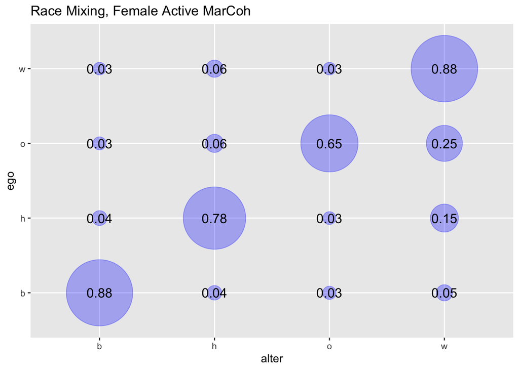

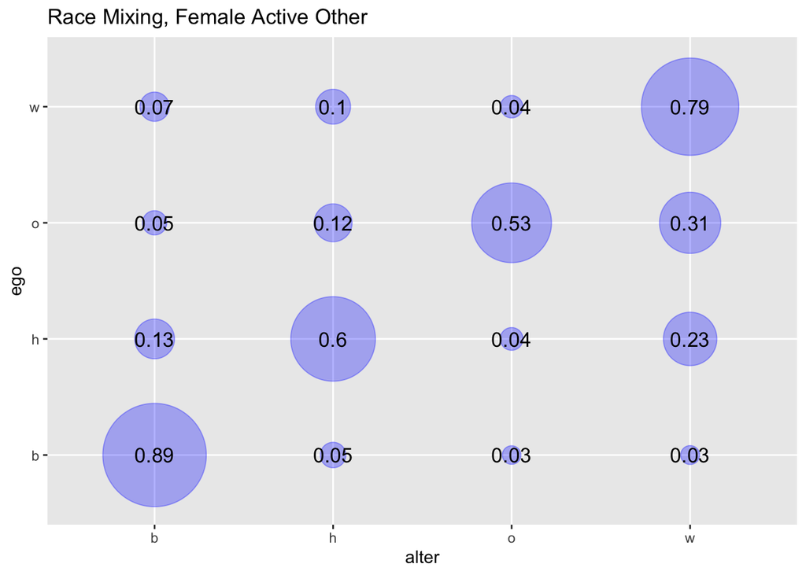

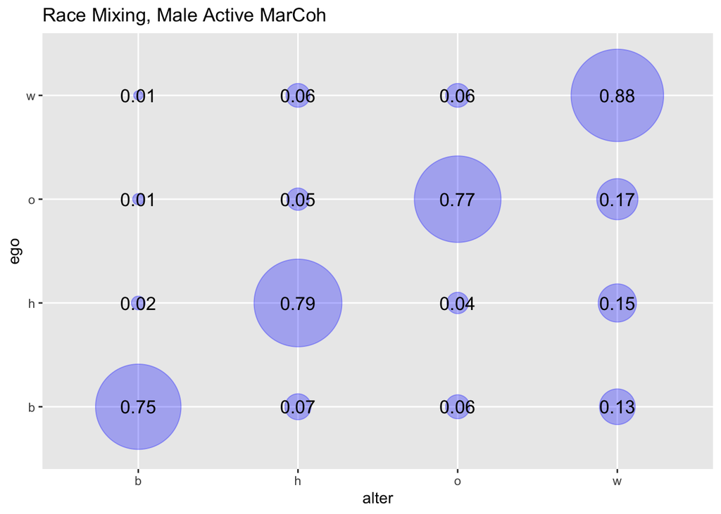

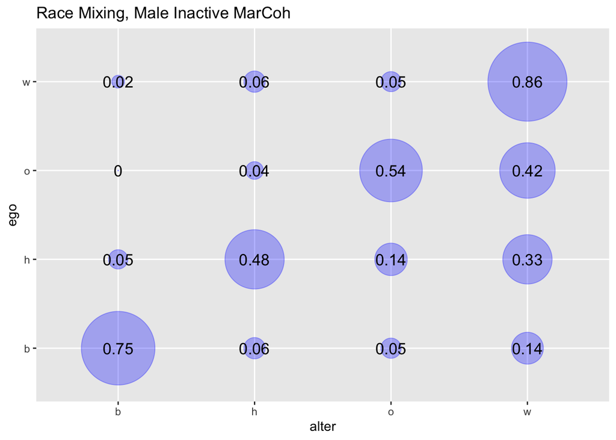